# Documentation

In this part, I will implement linear regression with one variable to predict profits for a food truck.Suppose you are the CEO of a restaurant franchise and are considering different cities for opening a new outlet. The chain already has trucks in various cities and you have data for profits and populations from the cities.

You would like to use this data to help you select which city to expand to next.

The file data1.txt contains the dataset for our linear regression prob- lem. The first column is the population of a city and the second column is the profit of a food truck in that city. A negative value for profit indicates a loss.

Library Packages:

```r
library(ggplot2)
```

Let’s see the original data first,there are two columns representing Population of City in 10,000s and Profit in $10,000s.

```r
data<-read.table("data1.txt",sep=",",header = F)
names(data)<-c("population","profit")
head(data)
```

```
##   population  profit
## 1     6.1101 17.5920
## 2     5.5277  9.1302
## 3     8.5186 13.6620
## 4     7.0032 11.8540
## 5     5.8598  6.8233
## 6     8.3829 11.8860
```

```r
summary(data)
```

```
##    population         profit
##  Min.   : 5.027   Min.   :-2.681
##  1st Qu.: 5.708   1st Qu.: 1.987
##  Median : 6.589   Median : 4.562
##  Mean   : 8.160   Mean   : 5.839
##  3rd Qu.: 8.578   3rd Qu.: 7.047
##  Max.   :22.203   Max.   :24.147
```

Plotting:

It is often useful to understand the data by visualizing it. For this dataset, we can use a scatter plot to visualize the data.

```
## geom_smooth: method="auto" and size of largest group is <1000, so using loess. Use 'method = x' to change the smoothing method.
```

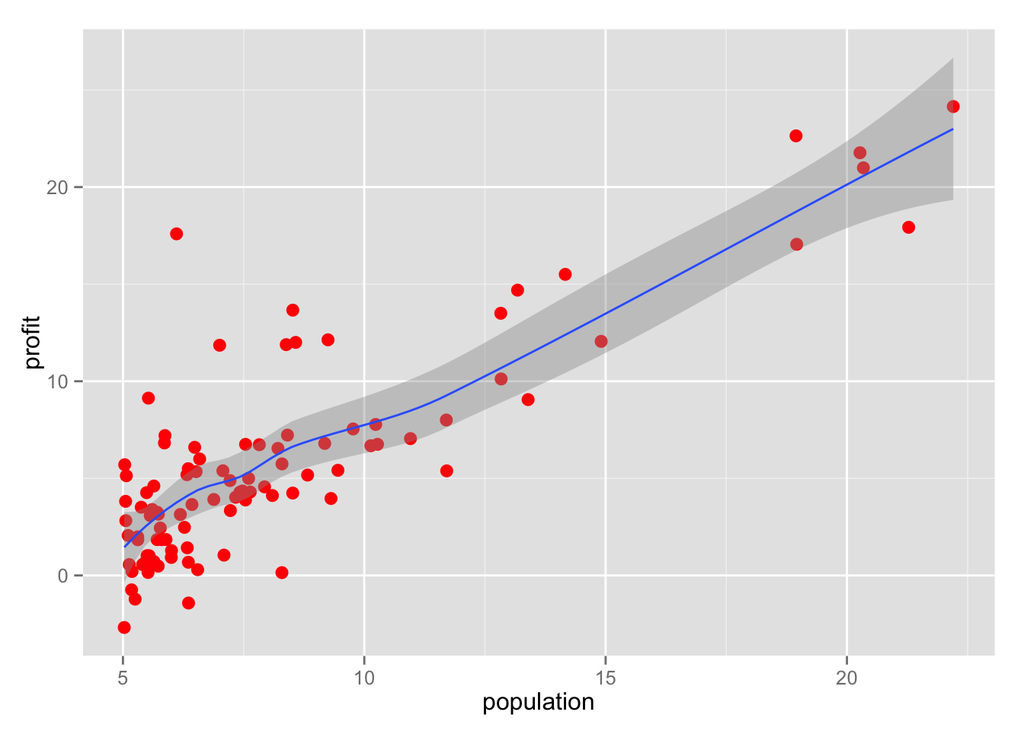

```r
ggplot(data,aes(x=population,y=profit))+geom_point(colour="red",size=3)+geom_smooth(type="lm")
```

Linear Regression,get the intercept and slope of the “best” straight line.

```r
fit<-lm(profit~population,data=data)
summary(fit)
```

```
##
## Call:
## lm(formula = profit ~ population, data = data)
##
## Residuals:
##     Min      1Q  Median      3Q     Max
## -5.8540 -1.9686 -0.5407  1.5360 14.1982
##
## Coefficients:
##             Estimate Std. Error t value Pr(>|t|)
## (Intercept) -3.89578    0.71948  -5.415 4.61e-07 ***
## population   1.19303    0.07974  14.961  < 2e-16 ***
## ---
## Signif. codes:  0 '***' 0.001 '**' 0.01 '*' 0.05 '.' 0.1 ' ' 1
##
## Residual standard error: 3.024 on 95 degrees of freedom
## Multiple R-squared:  0.702,  Adjusted R-squared:  0.6989
## F-statistic: 223.8 on 1 and 95 DF,  p-value: < 2.2e-16
```

```r
intercept<-fit$coefficients[1]
slope<-fit$coefficients[2]
```

Prediction

```r
predict_population=11.03
predict_profit=slope*predict_population+intercept
predict_profit
```

```
## population
##    9.26338
```

Conclusion

In this project, I implement linear regression and get to see it work on data about the profit changed by the population of the city.